# Multiplex Network Analysis

Feiya Zhang

2026-04-08

## Introduction

The study mainly utilized the tool from the package [statenet](https://github.com/statnet/ergm.multi) to analyze the multiplex network.

```r
pkgs <- c("ergm","network", "ggrepel","ergm.multi","dplyr","sna","tidyverse")

if (any(!sapply(pkgs, requireNamespace, quietly = TRUE))) {
  install.packages(pkgs)
}
# library(ergm)
library(network)
library(ergm.multi)
library(dplyr)
library(sna)
library(tidyverse)
# library(ggrepel)
```

The network consists of the same set of nodes (states) across layers, but the active nodes differ in each layer. Only states with ties in a given layer are considered ‘active’, while others are inactive, isolated nodes. To ensure comparability, the study first created the union of all states across both layers and mapped this union to each layer, so each network contains the same nodes. Since the package network uses numeric indices to identify nodes, a name-to-number mapping list was created at the outset. For edge weights, because the Poisson distribution requires integer values, the original weights were multiplied by 100. Apart from the orginal weighted network, Two processed versions of each network were prepared: one unweighted and one with integer weights for Poisson-related calculations. However, the study only used the unweighted network for research.

#NOTE el1/layer1/p: positive interaction layer el2/layer2/c: common issue layer

```r
el1 <- read.csv("../data/layer1/layer1_backbone_pos.csv")
el2 <- read.csv("../data/layer2/layer2_backbone_filtered.csv")
```

```r
glimpse(el1)
```

```
## Rows: 148
## Columns: 5
## $ s1        <chr> "Israel", "Israel", "Israel", "Israel", "Israel", "Palestine…
## $ s2        <chr> "Morocco", "South Sudan", "Serbia", "Thailand", "Papua New G…
## $ p_value   <dbl> 9.195700e-02, 2.351145e-01, 2.445741e-01, 4.293224e-01, 4.79…
## $ weight    <int> 7, 4, 5, 10, 2, 9, 7, 775, 15, 13, 4, 6, 18, 17, 4, 7, 19, 9…
## $ avg_score <dbl> 0.28571429, 0.50000000, 0.60000000, 0.30000000, 1.00000000, …
```

```r
glimpse(el2)
```

```
## Rows: 2,271
## Columns: 4
## $ source  <chr> "Bahamas", "Bahamas", "Bahamas", "Bahamas", "Bahamas", "Bahama…
## $ target  <chr> "Jamaica", "Dominican Republic", "Barbados", "Laos", "Haiti", …
## $ weight  <dbl> 0.9992257, 0.9864968, 0.8602023, 0.8391657, 0.8235538, 0.77269…
## $ p_value <dbl> 0.1670472, 0.1765054, 0.2205909, 0.2289312, 0.2353228, 0.25740…
```

```r
all_nodes <- sort(unique(c(el1$s1, el1$s2, el2$source, el2$target)))
n_nodes <- length(all_nodes)

node_map <- data.frame(
  node = all_nodes,
  id = seq_along(all_nodes)
)

# mapping ids to the nodes
el1_mapped <- merge(el1, node_map, by.x = "s1", by.y = "node", all.x = TRUE)
names(el1_mapped)[names(el1_mapped) == "id"] <- "source_id"
el1_mapped <- merge(el1_mapped, node_map, by.x = "s2", by.y = "node", all.x = TRUE)
names(el1_mapped)[names(el1_mapped) == "id"] <- "target_id"
el1_final <- el1_mapped[, c("source_id", "target_id", "avg_score")]

el2_mapped <- merge(el2, node_map, by.x = "source", by.y = "node", all.x = TRUE)
names(el2_mapped)[names(el2_mapped) == "id"] <- "source_id"
el2_mapped <- merge(el2_mapped, node_map, by.x = "target", by.y = "node", all.x = TRUE)
names(el2_mapped)[names(el2_mapped) == "id"] <- "target_id"
el2_final <- el2_mapped[, c("source_id", "target_id", "weight")]
```

```r
make_valued_net <- function(el, nodes, weight_col) {
  n <- length(nodes)
  net <- network.initialize(n, directed = FALSE)
  network.vertex.names(net) <- nodes
  add.edges(net, tail = el$source_id, head = el$target_id)
  # align weights
  el_net <- as.data.frame(as.edgelist(net))
  colnames(el_net) <- c("source_id", "target_id")
  el_net$weight <- NA
  for (i in 1:nrow(el_net)) {
    idx <- which(
      (el$source_id == el_net$source_id[i] & el$target_id == el_net$target_id[i]) |
      (el$source_id == el_net$target_id[i] & el$target_id == el_net$source_id[i])
    )
    if (length(idx) > 0) {
      el_net$weight[i] <- el[[weight_col]][idx[1]]
    }
  }
  set.edge.attribute(net, "weight", el_net$weight)
  return(net)
}

net1_valued <- make_valued_net(el1_final, all_nodes, 'avg_score')
net2_valued <- make_valued_net(el2_final, all_nodes, 'weight')
```

```r
make_unweighted_net <- function(el, nodes) {
  n <- length(nodes)
  net <- network.initialize(n, directed = FALSE)
  network.vertex.names(net) <- nodes
  network::add.edges(net, tail = el$source_id, head = el$target_id)
  return(net)
}

net1_unweighted <- make_unweighted_net(el1_final, all_nodes)
net2_unweighted <- make_unweighted_net(el2_final, all_nodes)
```

```r
make_poi_net <- function(el, nodes, weight_col) {
  n <- length(nodes)
  net <- network.initialize(n, directed = FALSE)
  network.vertex.names(net) <- nodes
  add.edges(net, tail = el$source_id, head = el$target_id)
  # align weights
  el_net <- as.data.frame(as.edgelist(net))
  colnames(el_net) <- c("source_id", "target_id")
  el_net$weight <- NA
  for (i in 1:nrow(el_net)) {
    idx <- which(
      (el$source_id == el_net$source_id[i] & el$target_id == el_net$target_id[i]) |
      (el$source_id == el_net$target_id[i] & el$target_id == el_net$source_id[i])
    )
    if (length(idx) > 0) {
      el_net$weight[i] <- as.integer(round(el[[weight_col]][idx[1]] * 100))
    }
  }
  set.edge.attribute(net, "weight", el_net$weight)
  return(net)
}

net1_poi <- make_poi_net(el1_final, all_nodes, 'avg_score')
net2_poi <- make_poi_net(el2_final, all_nodes, 'weight')
```

We may also be interested in the number of inactive nodes in each layer. The data shows that there are 82 inactive nodes in layer 1 and 3 inactive nodes in layer 2. Structurally, the network is an unaligned multicomplex network: it shares the same set of nodes across layers, but the number of active nodes differs in each layer.

```r
net1_num_isolates <- sum(degree(net1_unweighted) == 0)
net1_size <- network.size(net1_unweighted)
net2_num_isolates <- sum(degree(net2_unweighted) == 0)
net2_size <- network.size(net2_unweighted)

cat("inactivate node numer in the layer1: ", net1_num_isolates, "; total node number: ", net1_size, "\n")
```

```
## inactivate node numer in the layer1:  82 ; total node number:  182
```

```r
cat("inactivate node numer in the layer2: ", net2_num_isolates, "; total node number: ", net2_size, "\n")
```

```
## inactivate node numer in the layer2:  3 ; total node number:  182
```

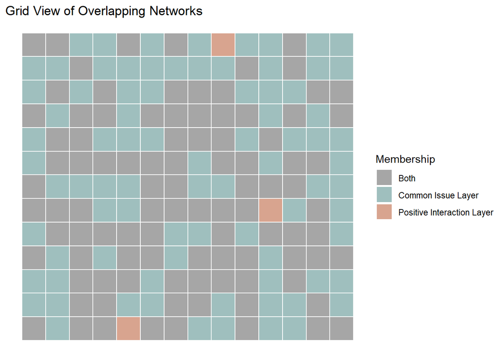

```r
# Extract node IDs from vertex.names
nodes <- network.vertex.names(net1_unweighted)

n <- length(nodes)
ncol_grid <- ceiling(sqrt(n))
nrow_grid <- ceiling(n / ncol_grid)

grid_df <- data.frame(
  node_id = nodes,
  x = rep(1:ncol_grid, length.out = n),
  y = rep(nrow_grid:1, each = ncol_grid, length.out = n),
  stringsAsFactors = FALSE
)

# Detect presence in each network
deg1 <- sna::degree(net1_unweighted)
deg2 <- sna::degree(net2_unweighted)

grid_df <- grid_df %>%
  mutate(
    in_net1 = deg1 > 0,
    in_net2 = deg2 > 0,
    group = case_when(
      in_net1 & in_net2 ~ "Both",
      in_net1 ~ "Positive Interaction Layer",
      in_net2 ~ "Common Issue Layer",
      TRUE ~ "None"
    )
  )
ggplot(grid_df, aes(x = x, y = y, fill = group)) +
  geom_tile(color = "white", size = 0.5) +
  scale_fill_manual(values = c(
    "Positive Interaction Layer" = "#D8A48F",
    "Common Issue Layer" = "#9FBFBE",
    "Both" = "#A6A6A6",
    "None" = "grey90"
  )) +
  coord_equal() +
  theme_void() +
  labs(
    title = "Grid View of Overlapping Networks",
    fill = "Membership"
  )
```

## Model Fitting

The study ran several default models on the data and evaluated their goodness of fit. Since the two layers are distinct, with the l-p layer being more sparse and the l-c layer more dense, they were treated separately.

### CMB

```r
unweighted_multi <- Layer(p=net1_unweighted,c=net2_unweighted)
fit_cmb <- ergm(unweighted_multi ~ L(~edges, ~.) + CMBL(~.))
```

```
## Starting maximum pseudolikelihood estimation (MPLE):
```

```
## Obtaining the responsible dyads.
```

```
## Evaluating the predictor and response matrix.
```

```
## Maximizing the pseudolikelihood.
```

```
## Finished MPLE.
```

```
## Starting Monte Carlo maximum likelihood estimation (MCMLE):
```

```
## Iteration 1 of at most 60:
```

```
## 1
```

```
## Optimizing with step length 1.0000.
```

```
## The log-likelihood improved by 0.0293.
```

[output not shown]

```r
summary(fit_cmb)
```

```
## Call:
## ergm(formula = unweighted_multi ~ L(~edges, ~.) + CMBL(~.))
##
## Monte Carlo Maximum Likelihood Results:
##
##            Estimate Std. Error MCMC % z value Pr(>|z|)
## L(.)~edges -2.90909    0.07569      0 -38.433   <1e-04 ***
## CMBL(~.)   -0.60460    0.11244      0  -5.377   <1e-04 ***
## ---
## Signif. codes:  0 '***' 0.001 '**' 0.01 '*' 0.05 '.' 0.1 ' ' 1
##
##      Null Deviance: 45667  on 32942  degrees of freedom
##  Residual Deviance: 17255  on 32940  degrees of freedom
##
## AIC: 17259  BIC: 17275  (Smaller is better. MC Std. Err. = 0.9796)
```

```r
gof_cmb <- gof(fit_cmb)
summary(gof_cmb)
```

[output not shown]

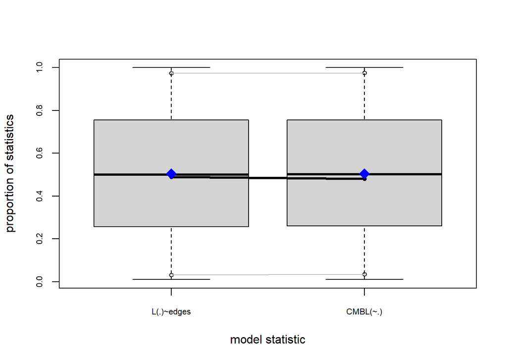

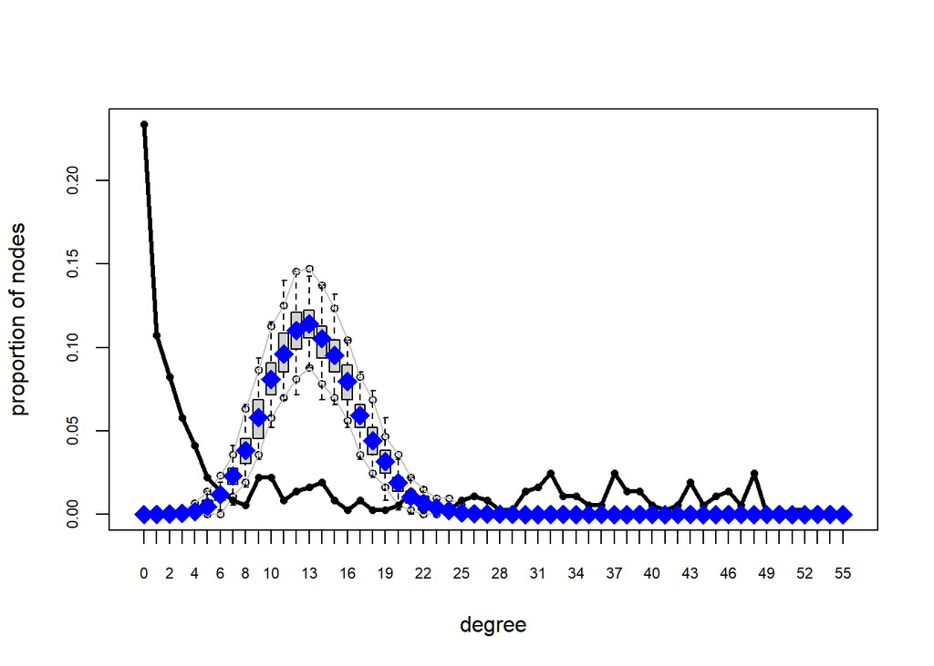

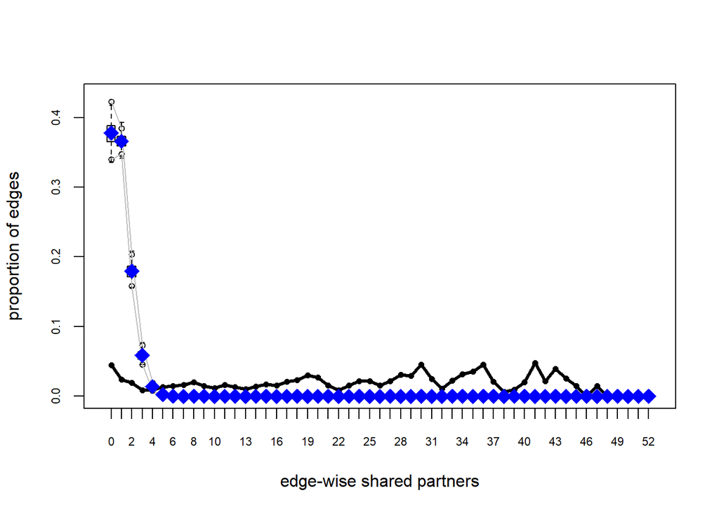

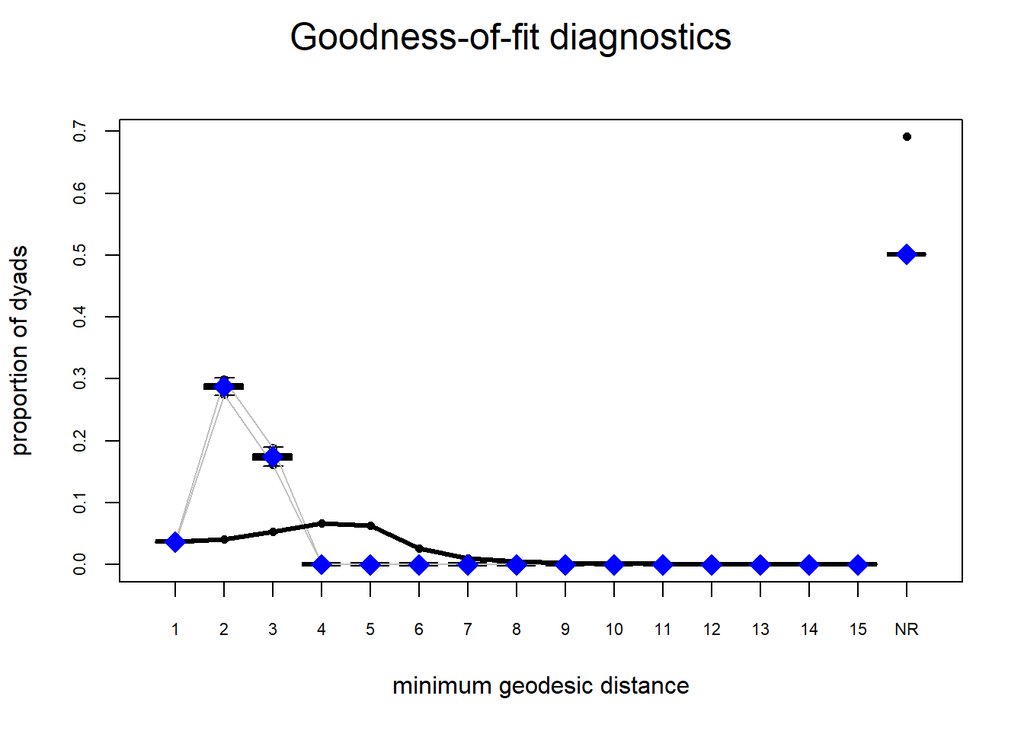

```r
plot(gof_cmb)
```

```r
fit_cmb_f1 <- ergm(
  unweighted_multi ~
    L(~edges, ~p) +   # allow p to have its own density
    # L(~gwesp(0.1, fixed=TRUE), ~p) +
    L(~edges, ~c) +
    # L(~gwesp(0.01, fixed=TRUE), ~c) +
    # L(~gwdegree(0.05, fixed=TRUE), ~c) +
    # L(~concurrent, ~c) +
    CMBL(~.),
    # estimator = "MPLE"
  control = control.ergm(
    seed = 1,
    MCMLE.maxit = 20,
    MCMC.samplesize = 10000
  )
)
```

```
## Starting maximum pseudolikelihood estimation (MPLE):
```

```
## Obtaining the responsible dyads.
```

```
## Evaluating the predictor and response matrix.
```

```
## Maximizing the pseudolikelihood.
```

```
## Finished MPLE.
```

```
## Starting Monte Carlo maximum likelihood estimation (MCMLE):
```

```
## Iteration 1 of at most 20:
```

[output not shown]

```r
summary(fit_cmb_f1)
```

```
## Call:
## ergm(formula = unweighted_multi ~ L(~edges, ~p) + L(~edges, ~c) +
##     CMBL(~.), control = control.ergm(seed = 1, MCMLE.maxit = 20,
##     MCMC.samplesize = 10000))
##
## Monte Carlo Maximum Likelihood Results:
##
##            Estimate Std. Error MCMC % z value Pr(>|z|)
## L(p)~edges -4.42523    0.09298      0 -47.595   <1e-04 ***
## L(c)~edges -1.38409    0.09361      0 -14.786   <1e-04 ***
## CMBL(~.)    0.66538    0.13473      0   4.939   <1e-04 ***
## ---
## Signif. codes:  0 '***' 0.001 '**' 0.01 '*' 0.05 '.' 0.1 ' ' 1
##
##      Null Deviance: 45667  on 32942  degrees of freedom
##  Residual Deviance: 14881  on 32939  degrees of freedom
##
## AIC: 14887  BIC: 14912  (Smaller is better. MC Std. Err. = 0.3564)
```

```r
gof_cmb_f1 <- gof(fit_cmb_f1)
summary(gof_cmb_f1)
```

[output not shown]

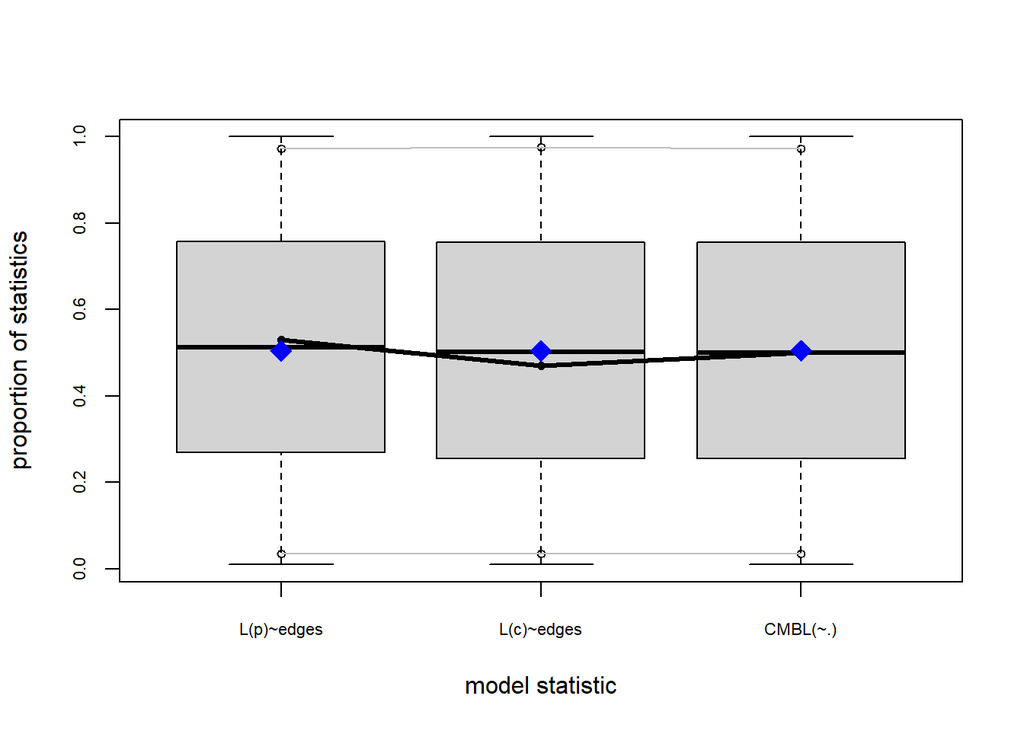

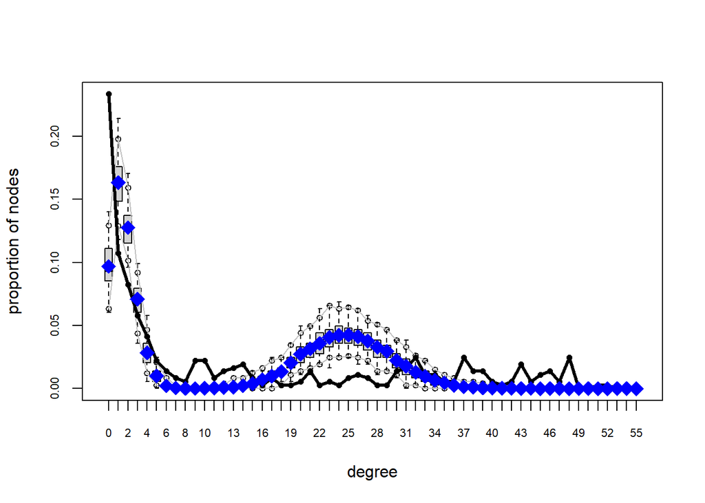

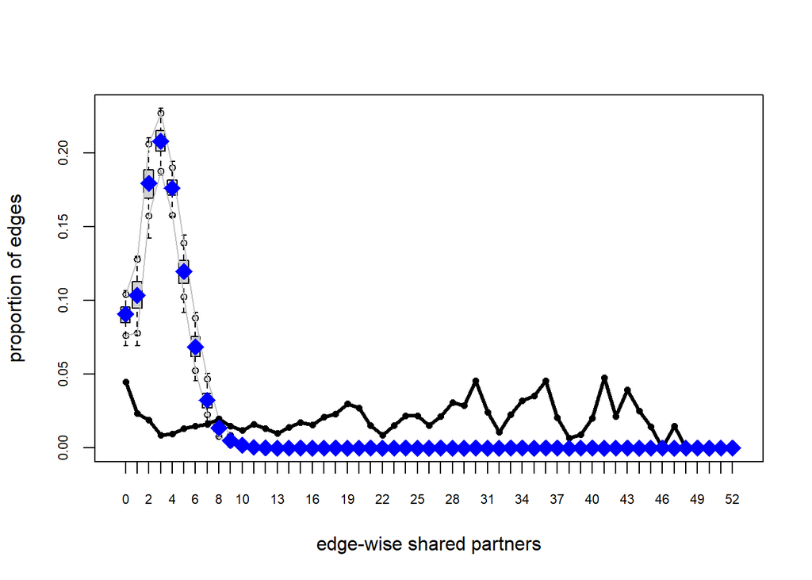

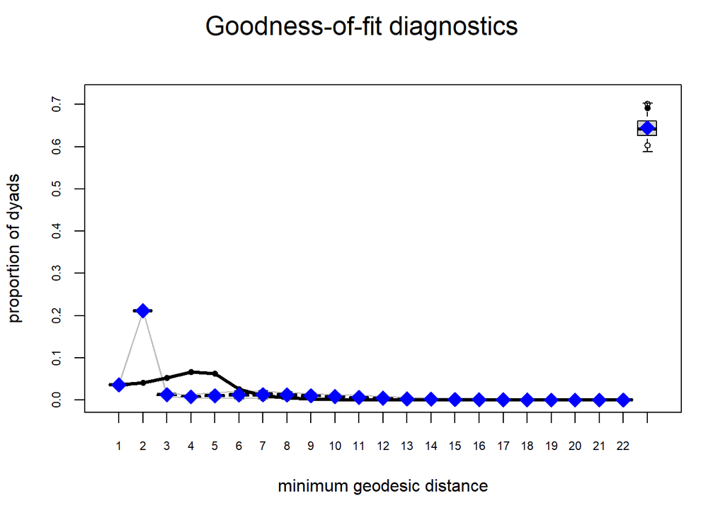

```r
plot(gof_cmb_f1)
```

```r
fit_cmb_f2 <- ergm(
  unweighted_multi ~
    L(~edges, ~p) +   # allow p to have its own density
    # L(~gwesp(0.1, fixed=TRUE), ~p) +
    L(~edges, ~c) +
    L(~gwesp(0.1, fixed=TRUE), ~c) +
    # L(~gwdegree(0.05, fixed=TRUE), ~c) +
    # L(~concurrent, ~c) +
    L(~gwdegree(0.5, fixed=TRUE), ~p) +
    L(~gwdegree(0.5, fixed=TRUE), ~c) +
    CMBL(~.),
    # estimator = "MPLE"
  control = control.ergm(
    seed = 4,
    MCMLE.maxit = 20,
    MCMC.samplesize = 10000
  )
)
```

```r
gof_cmb_f2 <- gof(fit_cmb_f2)
summary(gof_cmb_f2)
plot(gof_cmb_f2)
```

### AND

```r
fit_and <- ergm(
  unweighted_multi ~
    L(~edges, ~p) + L(~edges, ~c) + L(~edges, ~p&c),
  control = control.ergm(
    seed = 2,
    MCMLE.maxit = 20,
    MCMC.samplesize = 10000
  )
)
```

```
## Starting maximum pseudolikelihood estimation (MPLE):
```

```
## Obtaining the responsible dyads.
```

```
## Evaluating the predictor and response matrix.
```

```
## Maximizing the pseudolikelihood.
```

```
## Finished MPLE.
```

```
## Starting Monte Carlo maximum likelihood estimation (MCMLE):
```

```
## Iteration 1 of at most 20:
```

[output not shown]

```r
summary(fit_and)
```

```
## Call:
## ergm(formula = unweighted_multi ~ L(~edges, ~p) + L(~edges, ~c) +
##     L(~edges, ~p & c), control = control.ergm(seed = 2, MCMLE.maxit = 20,
##     MCMC.samplesize = 10000))
##
## Monte Carlo Maximum Likelihood Results:
##
##              Estimate Std. Error MCMC % z value Pr(>|z|)
## L(p)~edges   -4.88514    0.09776      0 -49.970   <1e-04 ***
## L(c)~edges   -1.84428    0.02217      0 -83.194   <1e-04 ***
## L(p&c)~edges  0.91227    0.17971      0   5.076   <1e-04 ***
## ---
## Signif. codes:  0 '***' 0.001 '**' 0.01 '*' 0.05 '.' 0.1 ' ' 1
##
##      Null Deviance: 45667  on 32942  degrees of freedom
##  Residual Deviance: 14880  on 32939  degrees of freedom
##
## AIC: 14886  BIC: 14912  (Smaller is better. MC Std. Err. = 0.3164)
```

```r
gof_and <- gof(fit_and)
summary(gof_and)
```

[output not shown]

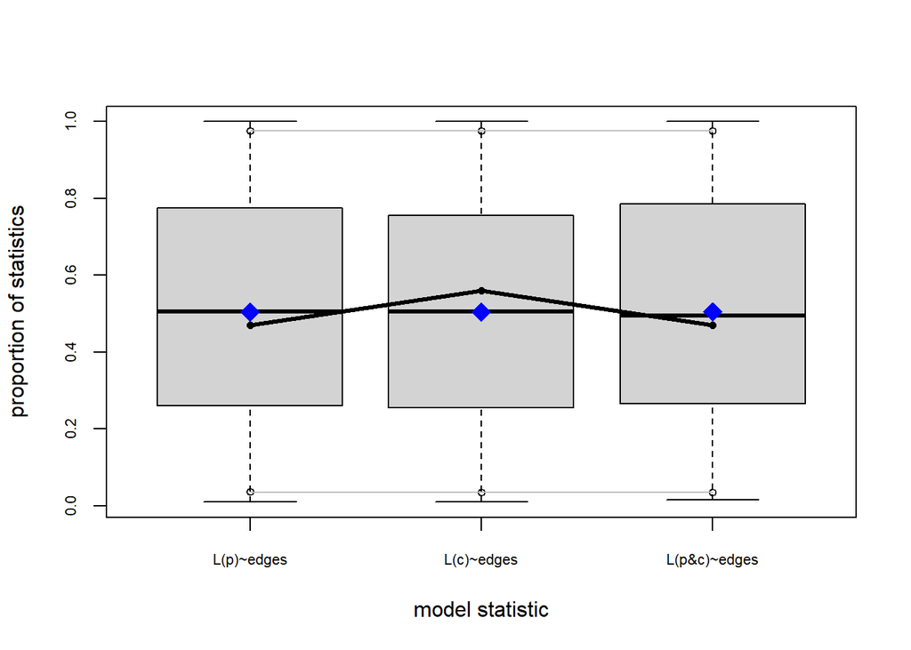

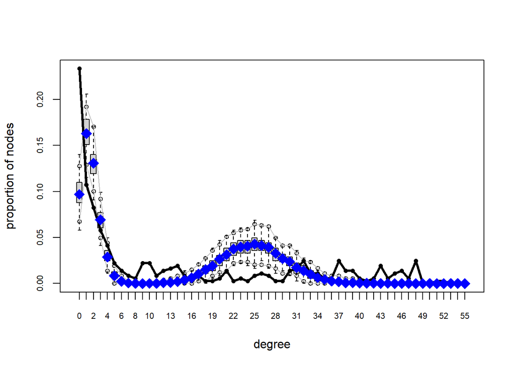

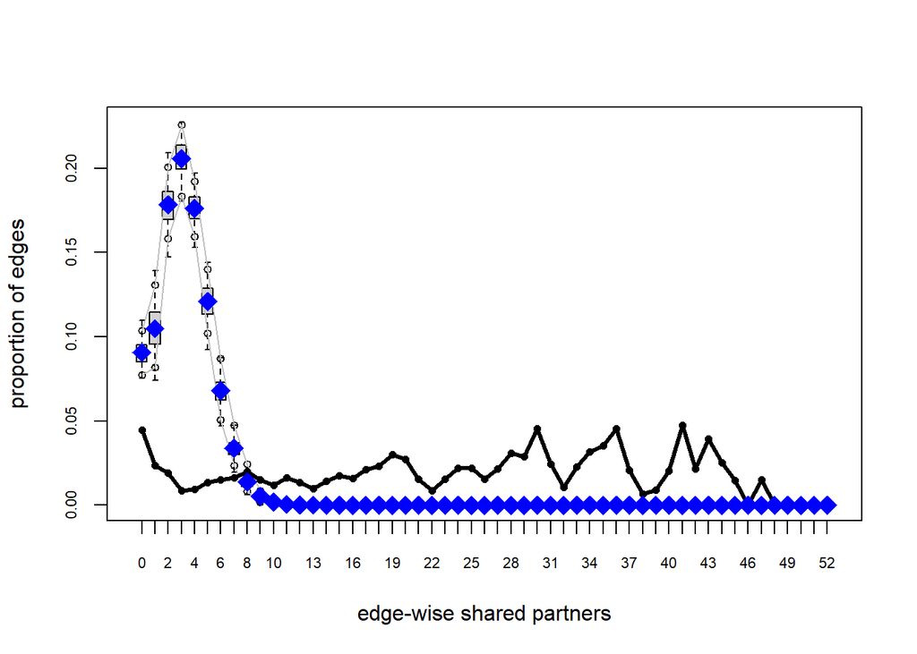

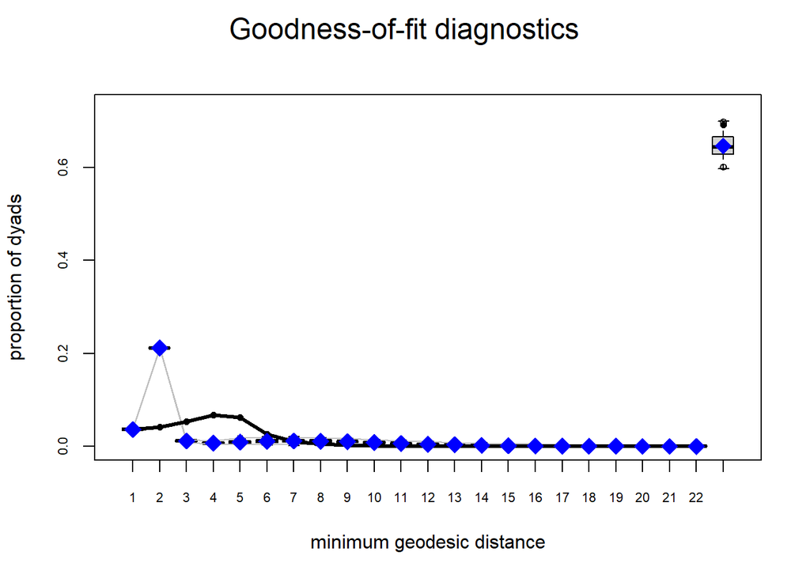

```r
plot(gof_and)
```

```r
unweighted_multi <- Layer(p=net1_unweighted,c=net2_unweighted)

fit_xor <- ergm(
  unweighted_multi ~L(~edges, ~p) + L(~edges, ~c) +
    L(~edges, ~xor(p,c))
)
```

```r
summary(fit_xor)
```

```r
gof_xor <- gof(fit_xor)
summary(gof_xor)
plot(gof_xor)
```

```r
unweighted_multi <- Layer(p=net1_unweighted,c=net2_unweighted)

fit_or <- ergm(
  unweighted_multi ~L(~edges, ~p) + L(~edges, ~c) + L(~edges, ~p|c)
)
```

```r
summary(fit_or)
```

```r
gof_or <- gof(fit_or)
summary(gof_or)
plot(gof_or)
```

```r
unweighted_multi <- Layer(p=net1_unweighted,c=net2_unweighted)

fit_2star_ndis <- ergm(
  unweighted_multi ~ edges + twostarL(list(~c, ~p), distinct = FALSE) +
  L(~edges, ~p&c),
  # CMBL(~.) degeneracy problem
  control = control.ergm(
    seed = 3,
    MCMLE.maxit = 20,
    MCMC.samplesize = 10000
  )
)
```

```
## Starting maximum pseudolikelihood estimation (MPLE):
```

```
## Obtaining the responsible dyads.
```

```
## Evaluating the predictor and response matrix.
```

```
## Maximizing the pseudolikelihood.
```

```
## Finished MPLE.
```

```
## Starting Monte Carlo maximum likelihood estimation (MCMLE):
```

```
## Iteration 1 of at most 20:
```

[output not shown]

```r
summary(fit_2star_ndis)
```

```
## Call:
## ergm(formula = unweighted_multi ~ edges + twostarL(list(~c, ~p),
##     distinct = FALSE) + L(~edges, ~p & c), control = control.ergm(seed = 3,
##     MCMLE.maxit = 20, MCMC.samplesize = 10000))
##
## Monte Carlo Maximum Likelihood Results:
##
##                 Estimate Std. Error MCMC % z value Pr(>|z|)
## edges          -1.635342   0.020681      0 -79.076   <1e-04 ***
## twostarL(c--p) -0.069403   0.002028      0 -34.229   <1e-04 ***
## L(p&c)~edges    1.157371   0.185689      0   6.233   <1e-04 ***
## ---
## Signif. codes:  0 '***' 0.001 '**' 0.01 '*' 0.05 '.' 0.1 ' ' 1
##
##      Null Deviance: 45667  on 32942  degrees of freedom
##  Residual Deviance: 14826  on 32939  degrees of freedom
##
## AIC: 14832  BIC: 14857  (Smaller is better. MC Std. Err. = 13.91)
```

```r
gof_2star <- gof(fit_2star_ndis)
summary(gof_2star)
```

[output not shown]

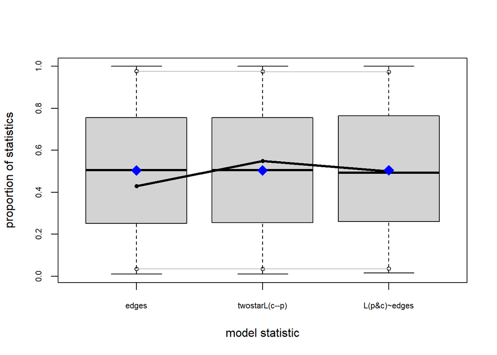

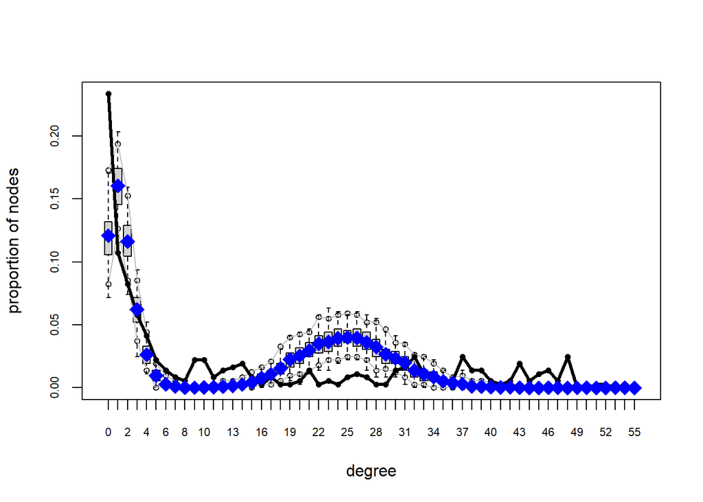

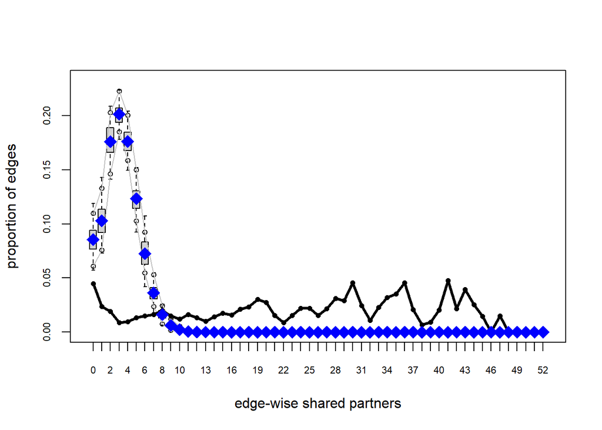

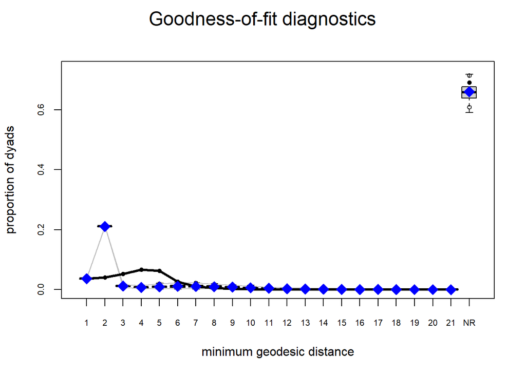

```r
plot(gof_2star)
```